# Reproducible Research: Peer Assessment 1

Edwin Seah

04 March 2015

## Loading and preprocessing the data

1. Load the data (i.e. `read.csv()`)
- We unzip the raw zip file containing activity data into a specified data directory within our working directory, and load it using `read.csv()` into a data frame called **df**. Integer is also specified as the type for *interval* to simplify transforming.

```r
unzip("activity.zip", exdir="data")
df <- read.csv("data/activity.csv",
               header=TRUE,
               colClasses=c("integer", "Date", "integer")
               )
```

2. Process/transform the data (if necessary) into a format suitable for your analysis
- We will use transform *date* and *interval* to form a new *hhmm* column in order to plot the data accurately. Instead of converting the interval to a POSIXlt object (which force-inserts an arbritary Date) we’ll use a sequential integer called *intervalID* that we attach to every interval using `cbind()` with replacement, knowing that there are always 288 5-min intervals per day. Checks on the original dataset dimensions reveal they are roundly divisible by 288 as well, showing there are indeed 61 unique days in the data set.

```r
df$hhmm=sprintf("%04d", df$interval)
df <- cbind(df, seq(unique(df$interval)))
names(df) <- c("steps", "date", "interval", "hhmm", "intervalID")
```

## What is mean total number of steps taken per day?

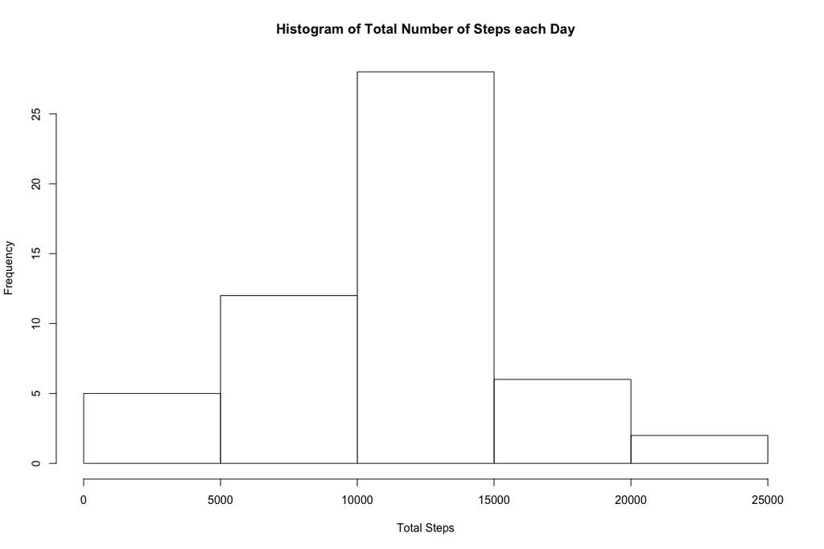

```r
library(dplyr)
# Create the NA-free data frame
# Have to remove interval, steps, hhmm and intervalID to make the hist from
# unique values
mts <- df[complete.cases(df),] %>%
    mutate(interval=NULL, hhmm=NULL, intervalID=NULL) %>%
    group_by(date) %>%
    mutate(totalSteps=sum(steps), steps=NULL) %>%
    unique()
# Plot the histogram
hist(mts$totalSteps,
     xlab="Total Steps",
     main="Histogram of Total Number of Steps each Day")
```

```r
mean(mts$totalSteps)
```

```
## [1] 10766.19
```

```r
median(mts$totalSteps)
```

```
## [1] 10765
```

## What is the average daily activity pattern?

1. Make a time series plot (i.e. `type = "l"`) of the 5-minute interval (x-axis) and the average number of steps taken, averaged across all days (y-axis)
- In order to make this plot, we’ll first create a data frame called **avgDaily**. This can be neatly done with **dplyr** again, by piping only the non-NA observations via `complete.cases()`, then calling `summarise_each()` on the groups of *intervalID* to obtain the means across all days for every interval. Then the plot can be made with `xyplot()` from the **lattice** plotting system. Because we had intentionally transformed the intervals into integer-based *intervalID* it plots faster and we get finer control over the x-axis display.

[figure not shown]

```r
# Derive a data frame that excludes all non-NA values
# We group by intervalID, hhmm, and interval so that we can use interval later
avgDaily <- df[complete.cases(df),] %>%
    group_by(intervalID, hhmm, interval) %>%
    summarise_each(funs(mean), steps)
# PLot using lattice
library(lattice)
xyplot(steps ~ intervalID,
       avgDaily,
       type="l",
       scales=list(x=list
                   (at=c(12, 48, 84, 120,
                         156, 192, 228, 264),
                    labels=c("01:00","04:00", "07:00", "10:00",
                             "13:00", "16:00", "19:00", "21:00"))),
       xlab="Interval",
       ylab="Average Number of Steps",
       main="Average Daily Activity Pattern of Steps per 5-min interval")
```

2. Which 5-minute interval, on average across all the days in the dataset, contains the maximum number of steps?
- We subset the **avgDaily** data frame by `max(avgDaily$steps)` to find the specific 5-minute interval which has the maximum number of steps, which is **835**. If we had not grouped by interval as well earlier on, the code would still be straightforward but a lot more tedious.

```r
avgDaily[avgDaily$steps==max(avgDaily$steps),]$interval
```

```
## [1] 835
```

## Imputing missing values

1. Calculate and report the total number of missing values in the dataset (i.e. the total number of rows with NAs)
- We use `!complete.cases()` on the original data frame **df** (giving us all rows with NAs) and put it in a new data frame called **missing**. Using `nrow()` on **missing** to count the number of rows, gives us **2304** rows.

```r
missing <- df[!complete.cases(df),]
nrow(missing)
```

```
## [1] 2304
```

2. Devise a strategy for filling in all of the missing values in the dataset. The strategy does not need to be sophisticated. For example, you could use the mean/median for that day, or the mean for that 5-minute interval, etc.
- We observe that there are **2304** NA rows from the original dataset, and **8** days when they do occur. Dividing the NA rows by the number of days with NA rows gives us exactly **288**, which is the exact number of 5-minute intervals per day. Since we already have the mean across all days for every 5-minute interval in the data frame **avgDaily**, our strategy for imputing the missing values simply re-uses the 5-minute interval means from **avgDaily** as fillers.
3. Create a new dataset that is equal to the original dataset but with the missing data filled in.
- Using `merge()` we perform a left join by *interval* on the data frames **df** and **avgDaily** which we place in a new data frame called **filled**. There are now *steps.x* and *steps.y* in **filled** which can then be passed through `mutate()` to fill in the missing values where there are NAs.

```r
# Using mean for each 5-minute interval from avgDaily to fill in missing values
filled <- merge(df, avgDaily,
                by=c("interval", "intervalID", "hhmm"),
                type="left",
                match="first")
filled <- filled  %>%
    mutate(steps=(ifelse(is.na(steps.x),
                         steps.y,
                         steps.x)
                  ),
           steps.x=NULL,
           steps.y=NULL)
```

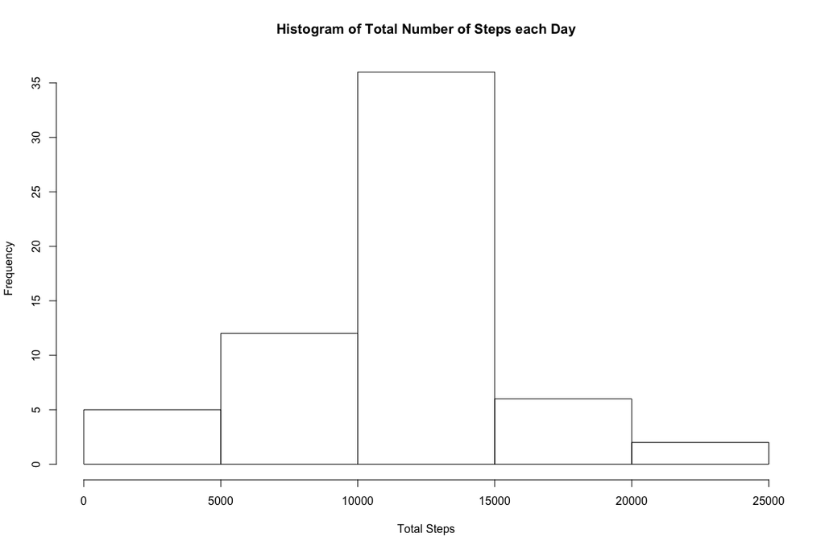

```r
# Make mtsImputed re-using code from making mts
mtsImputed <- filled %>%
    mutate(interval=NULL, hhmm=NULL, intervalID=NULL) %>%
    group_by(date) %>%
    mutate(totalSteps=sum(steps), steps=NULL) %>%
    unique()
# Make the histogram
hist(mtsImputed$totalSteps,
     xlab="Total Steps",
     main="Histogram of Total Number of Steps each Day")
```

- Imputation of the missing values did not change the mean from its estimate, but does make the median derived from imputed values slightly to match the mean.

**Mean and Median from Estimated set:**

```r
mean(mts$totalSteps)
```

```
## [1] 10766.19
```

```r
median(mts$totalSteps)
```

```
## [1] 10765
```

**Mean and Median from Imputed set:**

```r
mean(mtsImputed$totalSteps)
```

```
## [1] 10766.19
```

```r
median(mtsImputed$totalSteps)
```

```
## [1] 10766.19
```

## Are there differences in activity patterns between weekdays and weekends?

1. Create a new factor variable in the dataset with two levels – “weekday” and “weekend” indicating whether a given date is a weekday or weekend day.
- We mutate the *filled* data frame to add a new factor variable called *daytype*, which is populated as “weekend” if `weekdays(date)` is a `"Saturday"` or a `"Sunday"`, and “weekday” otherwise.

```r
filled <-
    filled %>%
    mutate (
        daytype = as.factor (
            ifelse (
                weekdays(date)=="Saturday" | weekdays(date)=="Sunday",
                "weekend",
                "weekday")
            )
        )
```

[figure not shown]

```r
# Munge the filled data frame to get average daily pattern by daytype and interval
filled <- filled %>%
    group_by(daytype, intervalID, hhmm, interval) %>%
    summarise_each(funs(mean), steps)
# Plot a panel with 1 col and 2 rows using xyplot
# We use the sequential intervalID instead of interval itself to avoid the time gaps
# It also allows us to conveniently set the scales for the x-axis
xyplot(steps ~ intervalID | daytype,
       filled,
       type="l",
       layout=c(1,2),
       scales=list(x=list(at=c(12, 48, 84, 120, 156, 192, 228, 264), labels=c("01:00","04:00", "07:00", "10:00", "13:00", "16:00", "19:00", "21:00"))),
       xlab="interval",
       main="Average Daily Activity Pattern of Steps per 5-min interval")
```